# Visualization_EDA_Project

#### Importing the Libraries

```python
import pandas as pd
import numpy as np
import seaborn as sns
import matplotlib.pyplot as plt
import warnings as wr
wr.filterwarnings("ignore")
```

#### Importing the dataset

```python
df = pd.read_csv(r"C:\Users\User\Python-Data Science-Inn\WebScrapping&Data_Cleaning_Project.csv")
```

```python
df.head()
```

|  | Unnamed: 0 | Name of Vehicle | Brand of Vehicle | Registration Year | Transmission | Fuel type | Kilometers Run | Price | Location of Vehicle | Name of City |
| --- | --- | --- | --- | --- | --- | --- | --- | --- | --- | --- |
| 0 | 0 | Hyundai i20 | Hyundai | 2012 | Manual | Petrol | 92054 | 377000 | Kompally | Hyderabad |
| 1 | 1 | Hyundai Elite i20 | Hyundai | 2018 | Manual | Diesel | 89269 | 763200 | Kompally | Hyderabad |
| 2 | 2 | Honda Amaze | Honda | 2018 | Manual | Petrol | 97090 | 605000 | Bachupally | Hyderabad |
| 3 | 3 | Maruti Alto 800 | Maruti | 2015 | Manual | Petrol | 72308 | 263000 | Bachupally | Hyderabad |
| 4 | 4 | Hyundai NEW SANTRO | Hyundai | 2018 | Automatic | Petrol | 92388 | 433000 | Attapur | Hyderabad |

```python
df.drop('Unnamed: 0',axis=1,inplace=True)      #Dropping unwanted column
```

```python
df.head()
```

|  | Name of Vehicle | Brand of Vehicle | Registration Year | Transmission | Fuel type | Kilometers Run | Price | Location of Vehicle | Name of City |
| --- | --- | --- | --- | --- | --- | --- | --- | --- | --- |
| 0 | Hyundai i20 | Hyundai | 2012 | Manual | Petrol | 92054 | 377000 | Kompally | Hyderabad |
| 1 | Hyundai Elite i20 | Hyundai | 2018 | Manual | Diesel | 89269 | 763200 | Kompally | Hyderabad |
| 2 | Honda Amaze | Honda | 2018 | Manual | Petrol | 97090 | 605000 | Bachupally | Hyderabad |
| 3 | Maruti Alto 800 | Maruti | 2015 | Manual | Petrol | 72308 | 263000 | Bachupally | Hyderabad |
| 4 | Hyundai NEW SANTRO | Hyundai | 2018 | Automatic | Petrol | 92388 | 433000 | Attapur | Hyderabad |

### Visualizations

#### Numeric Data

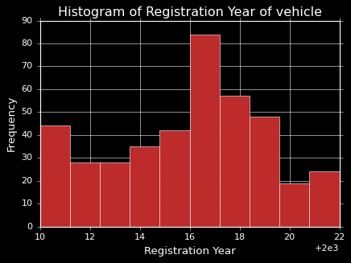

```python
plt.style.use('ggplot')
plt.style.use('dark_background')
df['Registration Year'].plot(kind = 'hist',
                             title = 'Histogram of Registration Year of vehicle',
                             xlabel = 'Registration Year',
                             color = '#bd2b2b',
                             figsize = (6,4))
```

- From the above plot we can see that most of the vehicles from 2017 year of Registration near about 90 vehicle
- And also i can see that there is minimum vehicles from 2020 year of registration

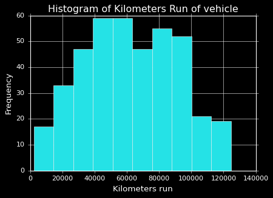

```python
plt.style.use('ggplot')
plt.style.use('dark_background')
df['Kilometers Run'].plot(kind = 'hist',
                             title = 'Histogram of Kilometers Run of vehicle',
                             xlabel = 'Kilometers run',
                             color = '#25e2e6',
                             figsize = (6,4))
```

- From the above plot i can see that most of the vehicles having Kilometers completed from 40000 to 60000
- And also i can see that there is minimum vehicles having kilometers completed from 10000 km and 120000 km

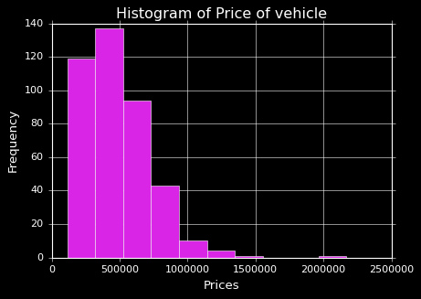

```python
plt.style.use('ggplot')
plt.style.use('dark_background')
df['Price'].plot(kind = 'hist',
                             title = 'Histogram of Price of vehicle',
                             xlabel = 'Prices',
                             color = '#d925e6',
                             figsize = (6,4))
```

- From above plot we can see there is most of vehiles prices under 5000000 (5 lakhs)
- That will be a good insight for us .

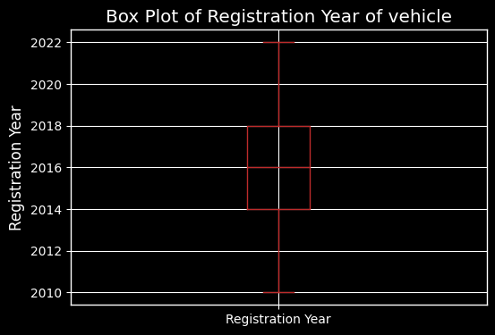

```python
plt.style.use('ggplot')
plt.style.use('dark_background')
df['Registration Year'].plot(kind = 'box',
                             title = 'Box Plot of Registration Year of vehicle',
                             ylabel = 'Registration Year',
                             color = '#bd2b2b',
                             figsize = (6,4))
```

- From a above Box plot we can see there is no outliers in data
- And the distance between both whisker is similar and middle line in median so we can see data is normally distributed

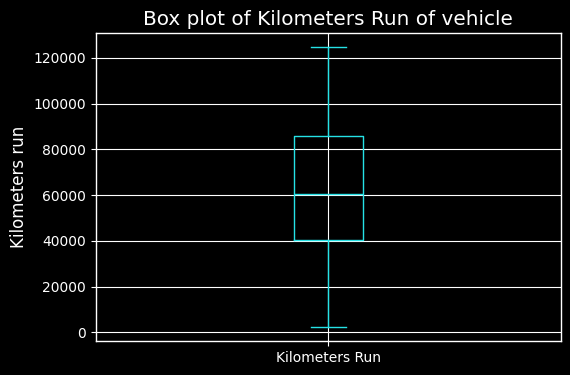

```python
plt.style.use('ggplot')
plt.style.use('dark_background')
df['Kilometers Run'].plot(kind = 'box',
                             title = 'Box plot of Kilometers Run of vehicle',
                             ylabel = 'Kilometers run',
                             color = '#25e2e6',
                             figsize = (6,4))
```

- From a above Box plot we can see there is no outliers in data
- And the distance between both whisker is similar and middle line in median so we can see data is normally distributed

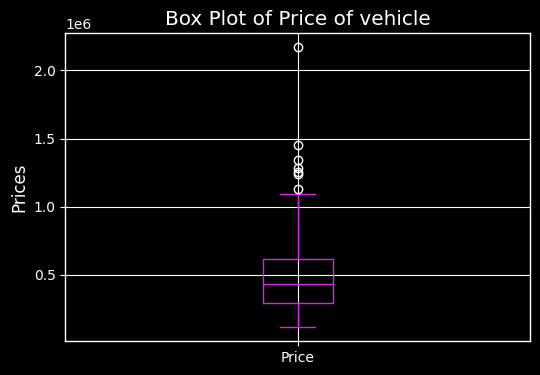

```python
plt.style.use('ggplot')
plt.style.use('dark_background')
df['Price'].plot(kind = 'box',
                             title = 'Box Plot of Price of vehicle',
                             ylabel = 'Prices',
                             color = '#d925e6',
                             figsize = (6,4))
```

- From a above Box plot we can see there is outliers in data of prices But it will not affect to my analysis because prices is true values

#### Categrical Data

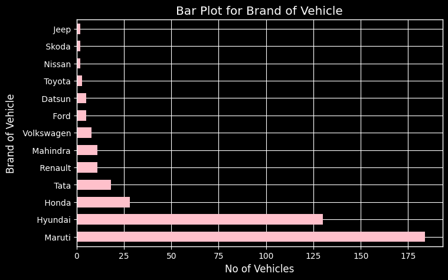

```python
plt.style.use('ggplot')
plt.style.use('dark_background')
df['Brand of Vehicle'].value_counts().plot(kind='barh',
                               color = 'pink',
                               grid = True,
                               width = 0.6,
                               title = 'Bar Plot for Brand of Vehicle',
                               figsize=(8,5),
                               ylabel='Brand of Vehicle',
                               xlabel = 'No of Vehicles')
```

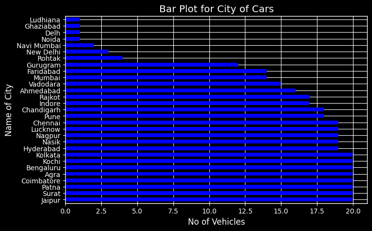

```python
plt.style.use('ggplot')
plt.style.use('dark_background')
df['Name of City'].value_counts().plot(kind='barh',
                               color = 'blue',
                               grid = True,
                               width = 0.6,
                               title = 'Bar Plot for City of Cars',
                               figsize=(8,5),
                               ylabel='Name of City',
                               xlabel = 'No of Vehicles')
```

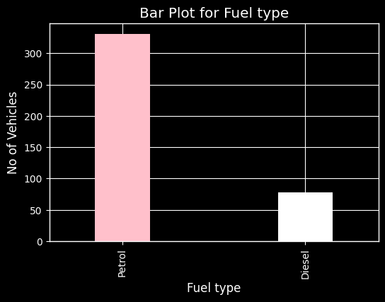

```python
df['Fuel type'].value_counts().plot(kind='bar',
                               color = ['pink','white'],
                               grid = True,
                               width = 0.3,
                               title = 'Bar Plot for Fuel type',
                               figsize=(6,4),
                               xlabel='Fuel type',
                               ylabel = 'No of Vehicles')
```

- From the above plot we can see there is most of the vahicle having Fuel type of Petrol near about 330 count
- And less vehicles having fuel type of Diesel near about 80 count

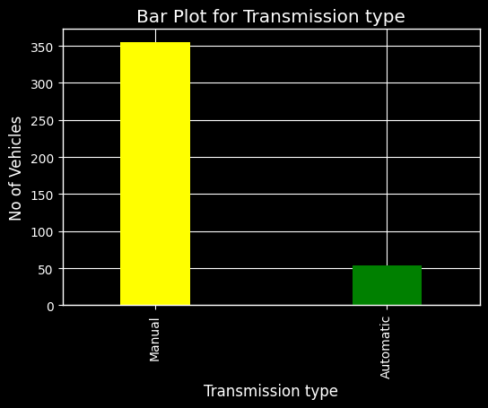

```python
df['Transmission'].value_counts().plot(kind='bar',
                               color = ['yellow','green'],
                               grid = True,
                               width = 0.3,
                               title = 'Bar Plot for Transmission type',
                               figsize=(6,4),
                               xlabel='Transmission type',
                               ylabel = 'No of Vehicles')
```

- From the above plot we can see there is most of the vahicle having Transmission type of Manual near about 360 count
- And less vehicles having Transmission of Automatic near about 50 count

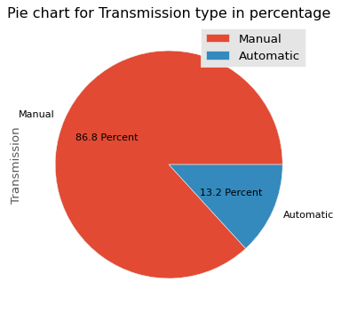

```python
plt.style.use('classic')
plt.style.use('ggplot')
(df['Transmission'].value_counts()/len(df['Transmission'])*100).plot(kind='pie',
                               figsize = (6,5),
                               legend = True,
                               autopct = '%1.1f'+' Percent' ,
                               ylabel = 'Transmission',
                               grid = True,
                               title = 'Pie chart for Transmission type in percentage')
```

- From above Pie chart we can see the percentages of vehicles transmission
- There is 86.8 percent of vehicles having Manual Transmission
- There is 13.2 percent of vehicles having Automatic Transmission

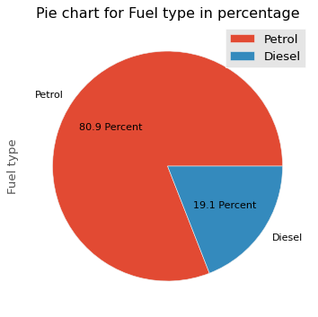

```python
plt.style.use('classic')
plt.style.use('ggplot')
(df['Fuel type'].value_counts()/len(df['Fuel type'])*100).plot(kind='pie',
                               figsize = (6,5),
                               legend = True,
                               autopct = '%1.1f'+' Percent' ,
                               ylabel = 'Fuel type',
                               grid = True,
                               title = 'Pie chart for Fuel type in percentage')
```

- From above Pie chart we can see the percentages of vehicles Fuel type
- There is 80.9 percent of vehicles having Petrol Fuel type
- There is 19.1 percent of vehicles having Diesel Fuel type

#### Categrical & Categgrical Data

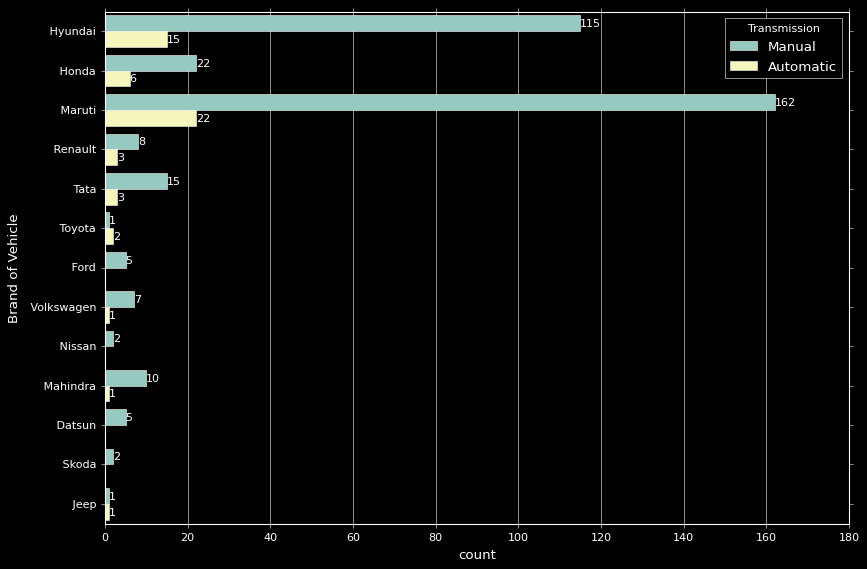

```python
plt.style.use('ggplot')
plt.style.use('dark_background')
plt.figure(figsize=(12,8))
ax = sns.countplot(data = df , y = 'Brand of Vehicle' , hue = 'Transmission',saturation = 0.75)
for i in ax.containers:
    ax.bar_label(i)
```

- From above plot we can see Highest vehicle coming from Maruti which is having Manual transmission
- second highest vehicle coming from Hyundai which is having Manual transmission

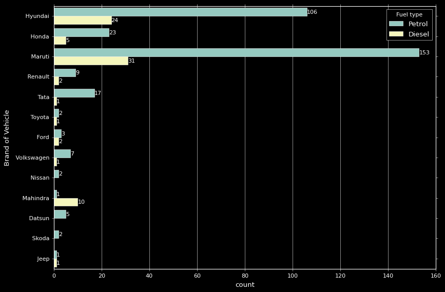

```python
plt.style.use('classic')
plt.style.use('ggplot')
plt.style.use('dark_background')
plt.figure(figsize=(12,8))
ax = sns.countplot(data = df , y = 'Brand of Vehicle' , hue = 'Fuel type')
for i in ax.containers:
    ax.bar_label(i)
```

- From above plot we can see Highest vehicle coming from Maruti which is running on petrol near about 153 counts
- second highest vehicle coming from Hyundai which is running on petrol near about 106 counts

#### Numeric & Numeric Data

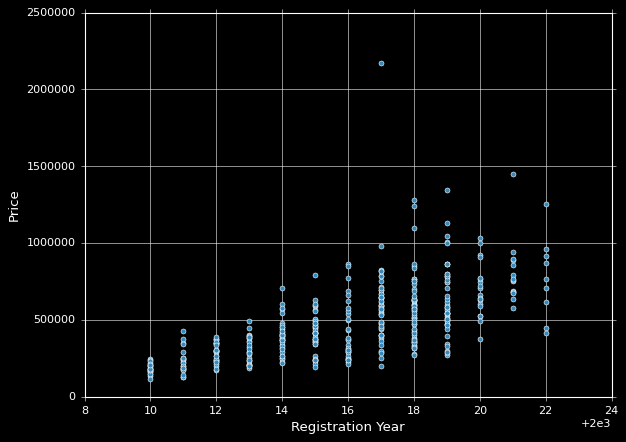

```python
df.plot('Registration Year','Price',kind='scatter',grid=True,figsize=(8.5,6))
```

- From the above Scatter plot the direction is positive because if the year of registration increasing so price also increasing
- And we can see strength is strong because scatter is little close to each other

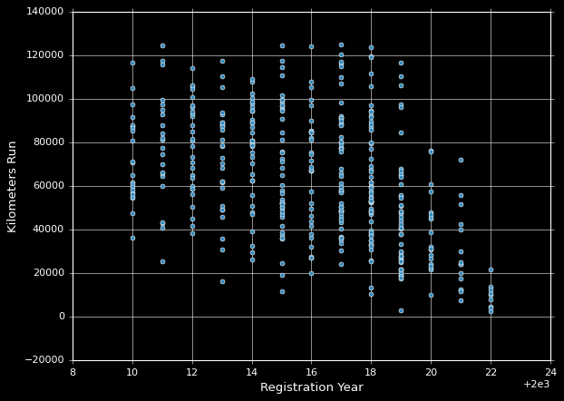

```python
df.plot('Registration Year','Kilometers Run',kind='scatter',grid=True,figsize=(8.5,6))
```

#### Numeric and Categric

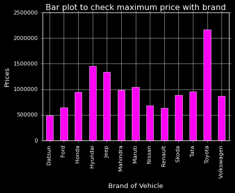

```python
plt.style.use('classic')
plt.style.use('ggplot')
plt.style.use('dark_background')
df.groupby(by='Brand of Vehicle')['Price'].max().plot(kind = 'bar',
                                                      color = '#fc03f4',
                                                      figsize=(6,4),
                                                      ylabel='Prices',
                                                      title = 'Bar plot to check maximum price with brand')
```

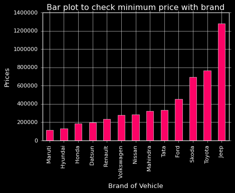

```python
plt.style.use('classic')
plt.style.use('ggplot')
plt.style.use('dark_background')
df.groupby(by='Brand of Vehicle')['Price'].min().sort_values().plot(kind = 'bar',
                                                      color = '#fc0366',
                                                      figsize=(6,4),
                                                      ylabel='Prices',
                                                      title = 'Bar plot to check minimum price with brand')
```

#### Analysis based on some conditions

```python
new = df[
    (df['Registration Year'] > 2015) &
    (df['Transmission'] == 'Manual') &
    (df['Fuel type'] == 'Petrol') &
    (df['Price'] < 500000)].reset_index(drop=True)
```

#### Heatmap

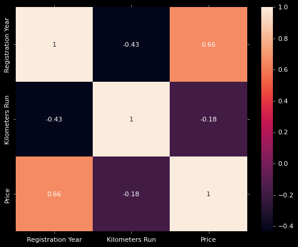

```python
sns.heatmap(df.corr(numeric_only=True),annot=True)
```

```python
df.corr(numeric_only=True)
```

|  | Registration Year | Kilometers Run | Price |
| --- | --- | --- | --- |
| Registration Year | 1.000000 | -0.432525 | 0.657271 |
| Kilometers Run | -0.432525 | 1.000000 | -0.179739 |
| Price | 0.657271 | -0.179739 | 1.000000 |

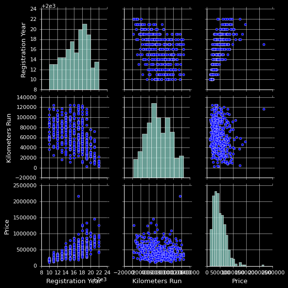

```python
sns.pairplot(df)
```

- Pair plot is the combination of scatter plot and histogram